# Worksheet for Discussion 2

Matthew Garvin

# Plotting exercises

## Overview:

Over the lecture last week, we went through the following three Known Graphs: 1. Scatter plot 2. Line plot 3. Histogram

# With everything going on in the world, let data make us feel empowered. Why don’t we do COVID plotting?

- Where to get the data?
  - https://covid19datahub.io/articles/api/r.html
- What to replicate?
  - CDC COVID Data Tracker - trends: https://covid.cdc.gov/covid-data-tracker/#trends_dailytrends

## Step 1: Installing the package

R has a COVID19 package that contains data on the status of the pandemic from around the world for different countries.

```r
# install the package - run the following command (without the "# " piece) in # Console
# install.packages("COVID19")

# load the package
library("COVID19")
library("ggplot2")
```

# Exercise 1. Line graph: new cases over time

## Get data for the US

```r
US_cases <- covid19(country = "US")
```

[output not shown]

### Explore what we have

```r
library(dplyr)
glimpse(US_cases)
```

```
## Rows: 239
## Columns: 35
## Groups: id [1]
## $ id                                  <chr> "USA", "USA", "USA", "USA", "US...
## $ date                                <date> 2020-01-22, 2020-01-23, 2020-0...
## $ tests                               <int> NA, NA, NA, NA, NA, NA, NA, NA,...
## $ confirmed                           <int> 1, 1, 2, 2, 5, 5, 5, 5, 5, 7, 8...
## $ recovered                           <int> NA, NA, NA, NA, NA, NA, NA, NA,...
## $ deaths                              <int> 0, 0, 0, 0, 0, 0, 0, 0, 0, 0, 0...
## $ hosp                                <int> NA, NA, NA, NA, NA, NA, NA, NA,...
## $ vent                                <int> NA, NA, NA, NA, NA, NA, NA, NA,...
## $ icu                                 <int> NA, NA, NA, NA, NA, NA, NA, NA,...
## $ population                          <int> 326687501, 326687501, 326687501...
## $ school_closing                      <int> 0, 0, 0, 0, 0, 0, 0, 0, 0, 0, 0...
## $ workplace_closing                   <int> 0, 0, 0, 0, 0, 0, 0, 0, 0, 0, 0...
```

[output cut: 23 more lines]

## Create new a column called “new_cases” for US from the existing data

```r
# This chunk will make sense after Friday's lecture
# We create a new column named "new_cases", to represent the increase in the number of confirmed cases on that day
US_cases <- US_cases %>%
  mutate(confirmed_yesterday = lag(confirmed, n=1), # create column that is previous days value
         new_cases = confirmed - confirmed_yesterday) # calculate difference
```

### Explore what we got after adding a new column

```r
glimpse(US_cases)
```

```
## Rows: 239
## Columns: 37
## Groups: id [1]
## $ id                                  <chr> "USA", "USA", "USA", "USA", "US...
## $ date                                <date> 2020-01-22, 2020-01-23, 2020-0...
## $ tests                               <int> NA, NA, NA, NA, NA, NA, NA, NA,...
## $ confirmed                           <int> 1, 1, 2, 2, 5, 5, 5, 5, 5, 7, 8...
## $ recovered                           <int> NA, NA, NA, NA, NA, NA, NA, NA,...
## $ deaths                              <int> 0, 0, 0, 0, 0, 0, 0, 0, 0, 0, 0...
## $ hosp                                <int> NA, NA, NA, NA, NA, NA, NA, NA,...
## $ vent                                <int> NA, NA, NA, NA, NA, NA, NA, NA,...
## $ icu                                 <int> NA, NA, NA, NA, NA, NA, NA, NA,...
## $ population                          <int> 326687501, 326687501, 326687501...
## $ school_closing                      <int> 0, 0, 0, 0, 0, 0, 0, 0, 0, 0, 0...
## $ workplace_closing                   <int> 0, 0, 0, 0, 0, 0, 0, 0, 0, 0, 0...
```

[output cut: 25 more lines]

### Check that the new_cases column is correct

Subtract the confirmed case counts for two consecutive days to get the number of new_cases for a later date

```r
library(knitr)
kable(
    head( US_cases[c( 'date', 'new_cases','confirmed')],
          n=10
    )
)
```

| date | new_cases | confirmed |
| --- | --- | --- |
| 2020-01-22 | NA | 1 |
| 2020-01-23 | 0 | 1 |
| 2020-01-24 | 1 | 2 |
| 2020-01-25 | 0 | 2 |
| 2020-01-26 | 3 | 5 |
| 2020-01-27 | 0 | 5 |
| 2020-01-28 | 0 | 5 |
| 2020-01-29 | 0 | 5 |
| 2020-01-30 | 0 | 5 |
| 2020-01-31 | 2 | 7 |

## Get new_cases for Canada

```r
Canada_cases <- covid19(country = "CAN")
# Create
Canada_cases <- Canada_cases %>%
  mutate(confirmed_yesterday = lag(confirmed, n=1), # create column that is previous days value
         new_cases = confirmed - confirmed_yesterday) # calculate difference
```

## Exercise 1: Why is Chris in Canada

In this exercise, we will plot line graphs to compare new cases in US and Canada.

### Part 1: Line graph for new cases in the US

Draw a line plot with `date` on the x-axis and `new_cases` on the y-axis, using the `US_cases` dataframe.

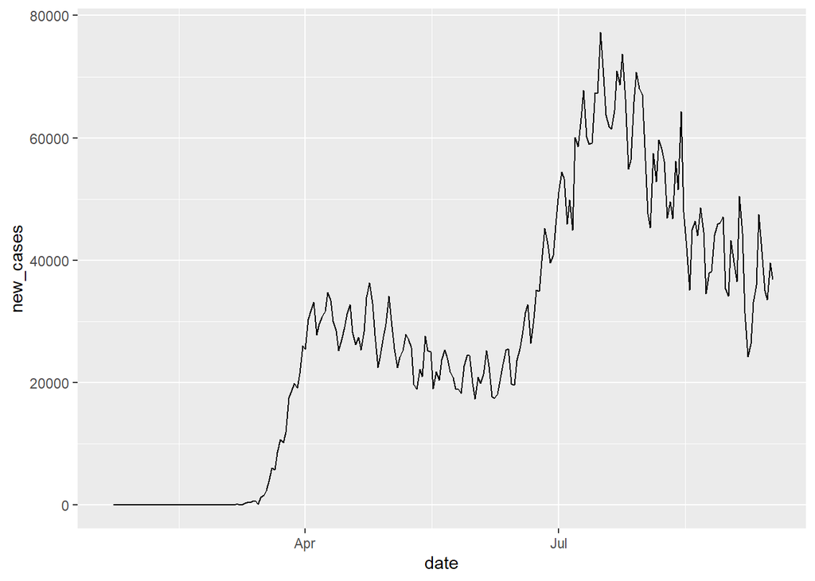

```r
# Type your code here
# Hint: which package do you need for plotting?
ggplot(data = US_cases, mapping = aes(x = date, y = new_cases)) + geom_line()
```

### Part 2: Line graph for new cases in the Canada

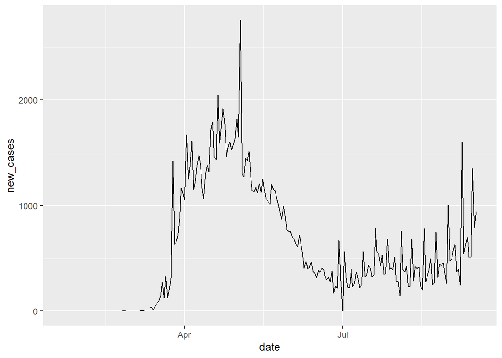

```r
# Type your code here
ggplot(data = Canada_cases, mapping = aes(x = date, y = new_cases)) + geom_line()
```

### Part 3: wait, but why is Chris in Canada?

Try to overlay the two line graphs with the same x-axis. Use different colors to differentiate the two lines.

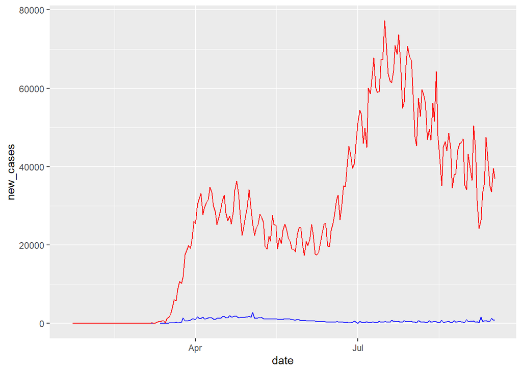

```r
# Type your code here
# Hint: first, plot one line graph as usual;
#       then, "add" the second line graph to the one you created in the first step
#       (recall adding layers from the lecture).
ggplot() + geom_line(data = Canada_cases, mapping = aes(x = date, y = new_cases), color="blue") +
  geom_line(data = US_cases, mapping = aes(x = date, y = new_cases), color="red")
```

# Exercise 2: How well are the states testing for COVID19? (Snapshot of Saturday, 2020-09-12)

## Setting things up

Get state-level data from the dataset

```r
US_statelevel = covid19(country = "US", level = 2)
```

[output not shown]

```r
# Check and confirm that the `administrative_area_level_2` column contains the State info;
# These are the available occurrances of each state in the dataset.
table(US_statelevel$administrative_area_level_2)
```

```
##
##                  Alabama                   Alaska           American Samoa
##                      194                      195                      185
##                  Arizona                 Arkansas               California
##                      197                      195                      197
##                 Colorado              Connecticut                 Delaware
##                      196                      194                      195
##     District of Columbia                  Florida                  Georgia
##                      196                      197                      197
##                     Guam                   Hawaii                    Idaho
##                      185                      194                      194
##                 Illinois                  Indiana                     Iowa
##                      197                      195                      195
##                   Kansas                 Kentucky                Louisiana
##                      195                      195                      194
##                    Maine                 Maryland            Massachusetts
##                      194                      196                      239
##                 Michigan                Minnesota              Mississippi
##                      200                      195                      194
##                 Missouri                  Montana                 Nebraska
##                      194                      194                      196
##                   Nevada            New Hampshire               New Jersey
##                      196                      197                      220
##               New Mexico                 New York           North Carolina
##                      195                      197                      197
##             North Dakota Northern Mariana Islands                     Ohio
##                      194                      185                      196
##                 Oklahoma                   Oregon             Pennsylvania
##                      194                      197                      195
##              Puerto Rico             Rhode Island           South Carolina
##                      185                      200                      197
##             South Dakota                Tennessee                    Texas
##                      194                      196                      197
##                     Utah                  Vermont           Virgin Islands
##                      194                      195                      185
##                 Virginia               Washington            West Virginia
##                      203                      239                      195
##                Wisconsin                  Wyoming
##                      197                      194
```

Take a snapshot of 2020-09-12, and plot the histogram of number of tests per 100,000 population:

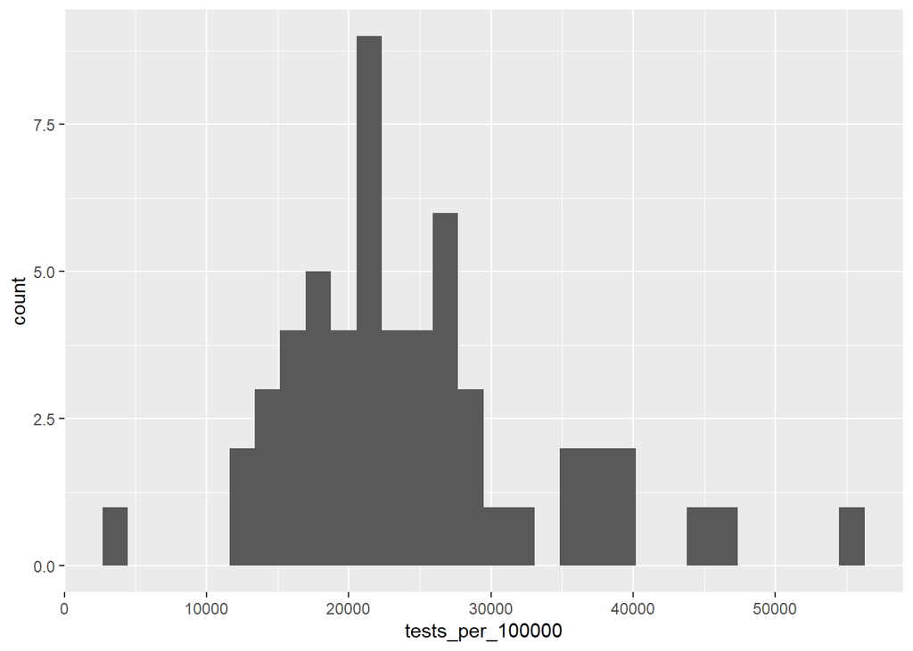

```r
# These will become natural after the lecture on Friday :)
df_2020_09_12 = US_statelevel %>%
  filter(date == "2020-09-12")

# And, plot using "pipes"
df_2020_09_12 %>%
  mutate(tests_per_100000 = tests / population * 100000) %>%
  ggplot(mapping = aes(x = tests_per_100000)) +
  geom_histogram()
```

From what you plotted above, what is the approx. testing rate for the majority of the states?

## Exercise 2.1: replicate the histogram above

Let’s do it step-by-step here:

### Step 1: construct a dataframe with “tests_per_100000” column

```r
# Let's do it step by step
df_Sunday =  df_2020_09_12
# Pause: check how many columns does df_Sunday have?
df_Sunday = df_Sunday %>%
  mutate(tests_per_100000 = tests / population * 100000)
# Pause: check again how many columns does df_Sunday have?
```

This is a preview of the `mutate` function: it keeps all columns in the dataframe and add the ones that are newly created per its arguments.

### Step 2: reproduce the histogram for the distribution of `tests_per_100000`

Note, please use `color=` argument and `binwidth=` argument to make your histogram more readable.

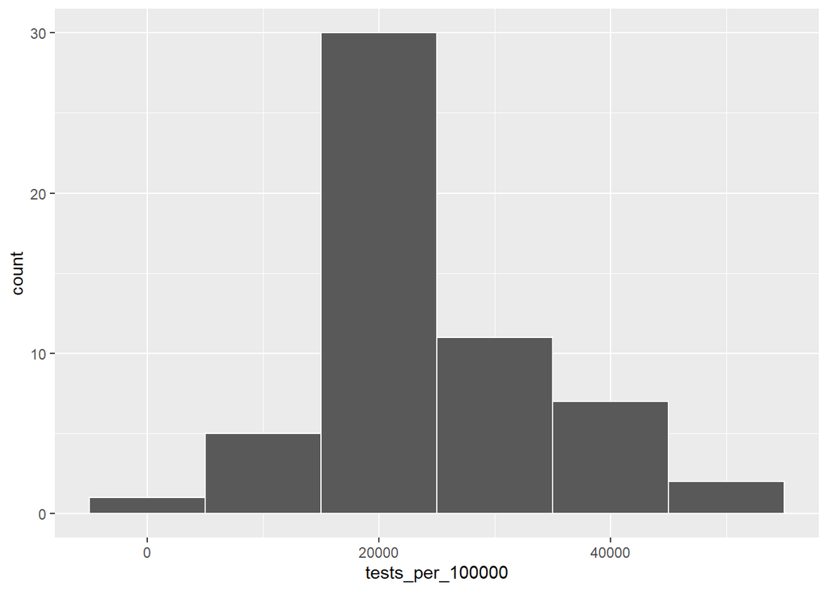

```r
# Type your code here
ggplot(data = df_Sunday, mapping = aes(x = tests_per_100000)) +
  geom_histogram(color = "white", binwidth = 10000)
```

What do you observe? In particular, which bin is the tallest? What does this imply?

## Exercise 3: construct a bar-plot of tests_per_100000 over all the states

```r
# Prep: we need to recode the state variable, as below
df_Sunday$state = df_Sunday$administrative_area_level_2
```

Now, use the newly created `state` variable to plot the bar plot.

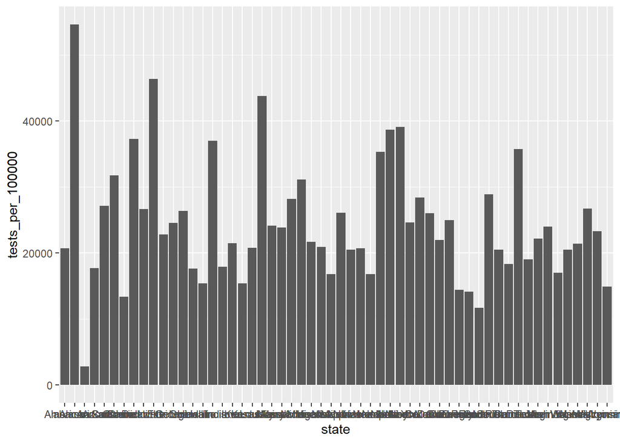

```r
# Type your code here
ggplot(data = df_Sunday, mapping = aes(x = state, y = tests_per_100000)) +
  geom_col()
```

Can you read the text labels on the x-axis, for all the states? If not, try to “add” the following code towards the end of your chunk:

```
  theme(axis.text.x = element_text(angle=60, hjust=1)) +
```

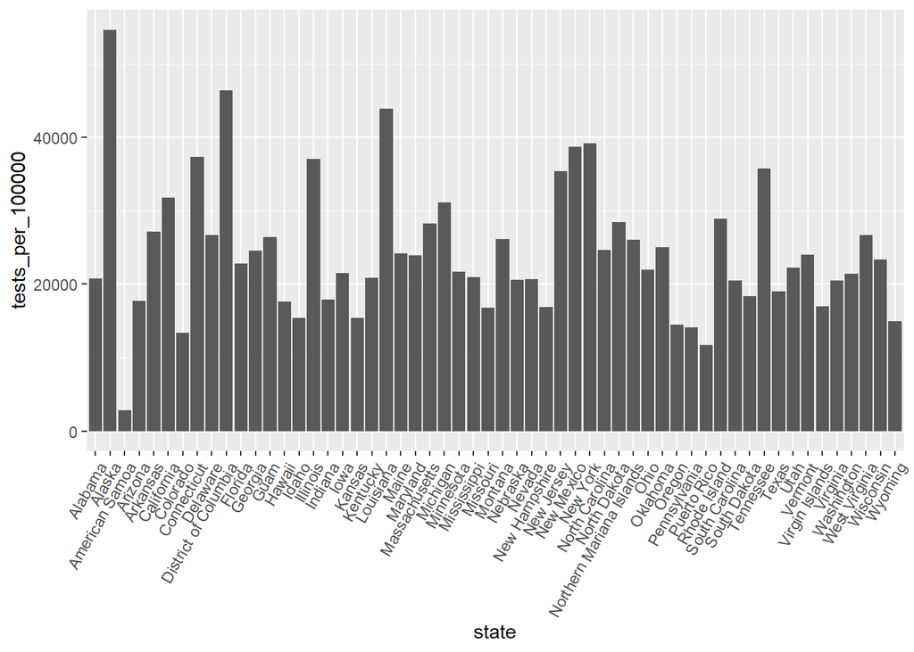

```r
# Type your code here, with readable x-axis labels:
ggplot(data = df_Sunday, mapping = aes(x = state, y = tests_per_100000)) +
  theme(axis.text.x = element_text(angle=60, hjust=1)) +
  geom_col()
```

From the histogram, we saw that a majority of states are testing around 20,000 out of 100,000 (or 2 out of 10). Can we confirm this in the bar plot?

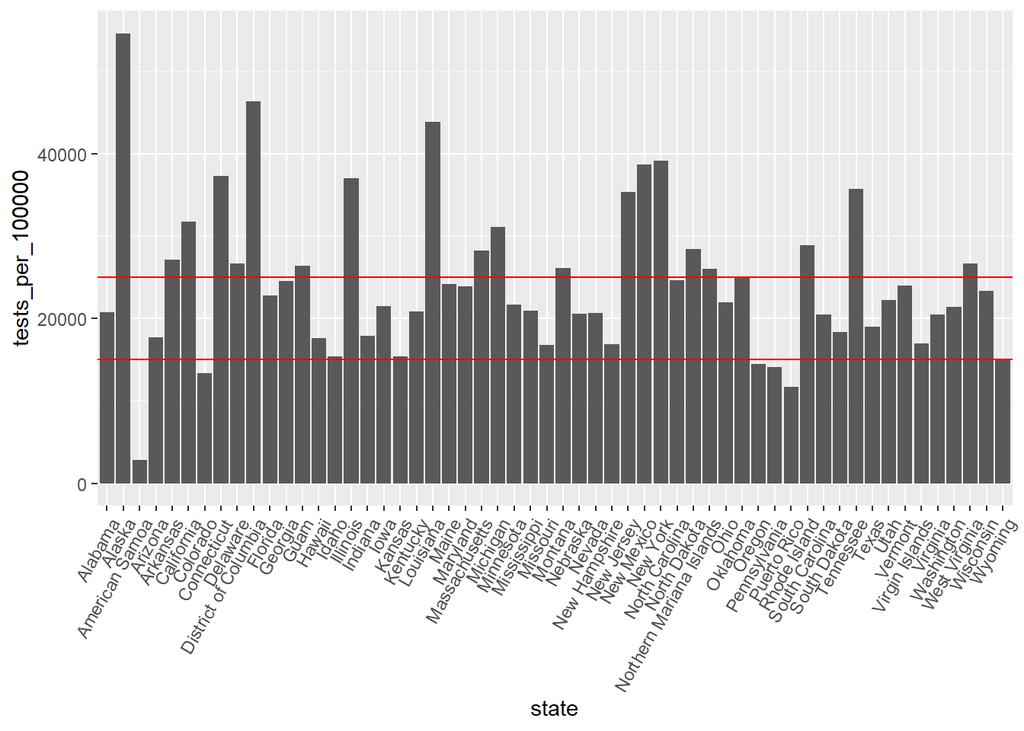

```r
# Type your code here
# Hint: draw a line at 20000
ggplot(data = df_Sunday, mapping = aes(x = state, y = tests_per_100000)) +
  theme(axis.text.x = element_text(angle=60, hjust=1)) +
  geom_col() +
  geom_abline(slope=0, intercept = 15000, color='red') + #draw a horizontal line (slope=0)
  geom_abline(slope=0, intercept = 25000, color='red') #draw a horizontal line (slope=0)
```